# ADC Exposure-Response Modeling: Linking Pharmacokinetics to Tumor Growth Inhibition and Survival

An oncology drug-disease modeling extension using simulated antibody-drug conjugate therapy

Juliette Bouli-Mengue

## 1. Motivation

In oncology drug development, tumor dynamics models are often combined with pharmacokinetic/pharmacodynamic (PK/PD) models to characterize how drug exposure translates into tumor response and survival outcomes. This notebook extends the tumor dynamics framework from notebooks 1-2 by introducing an explicit ADC (antibody-drug conjugate) exposure-response relationship:

**ADC administration → PK model (concentration over time) → PD model (drug effect) → Tumor Growth Inhibition model → Survival model (OS)**

*Note on units: growth and PK/PD parameters in this notebook are all expressed on a per-day time scale, consistent with the day-level dosing schedules typical of ADC regimens. Where a parameter is reused from notebooks 1-2 (defined on a per-week scale there), it is explicitly converted to per-day here — see Section 3.*

```r
library(dplyr)
library(ggplot2)
library(survival)
library(survminer)

set.seed(42)
```

## 2. Loading the simulated population

We reuse the simulated oncology population generated in notebook 1: each patient has individual tumor growth parameters (`g`, `d`) and baseline tumor size (`SLD0`). Baseline disease-only survival parameters (`os_time`, `os_event`) from the earlier drug-agnostic hazard model are retained for reference, but survival under treatment is regenerated in Section 9 through the tumor-response hazard model, not reused as-is.

```r
# Assumes patients_final.rds is saved in the same folder as this notebook
# (produced by notebook 1) — a relative path, so the project stays portable
# across machines. Note: longitudinal_data_final.rds is not loaded here, since
# this notebook works from the mechanistic TGI trajectories simulated in
# Section 7, not from the raw longitudinal scan data used in notebooks 1-2.
patients <- readRDS("patients_final.rds")
```

## 3. Fixing the time-scale/unit mismatch

`g` was defined in notebook 1 as a **per-week** regression rate. This notebook works on a **per-day** time grid (ADC dosing and PK elimination are naturally described in days). Reusing `g` directly in a per-day growth equation would silently inflate tumor growth by a factor of 7. We convert it explicitly once, here:

```r
patients <- patients %>%
  mutate(g_daily = g / 7)

summary(patients$g_daily)
```

```
##      Min.   1st Qu.    Median      Mean   3rd Qu.      Max.
## 0.0006397 0.0021059 0.0028338 0.0031637 0.0039221 0.0110316
```

All growth terms in this notebook use `g_daily`, never the original weekly `g`.

## 4. ADC pharmacokinetic model (single representative patient)

A one-compartment PK model describes ADC plasma concentration over time:

$$C(t) = \frac{Dose}{V} \, e^{-k_{el}
t}$$

- `Dose`: administered ADC dose
- `V`: volume of distribution
- `k_el`: elimination rate constant

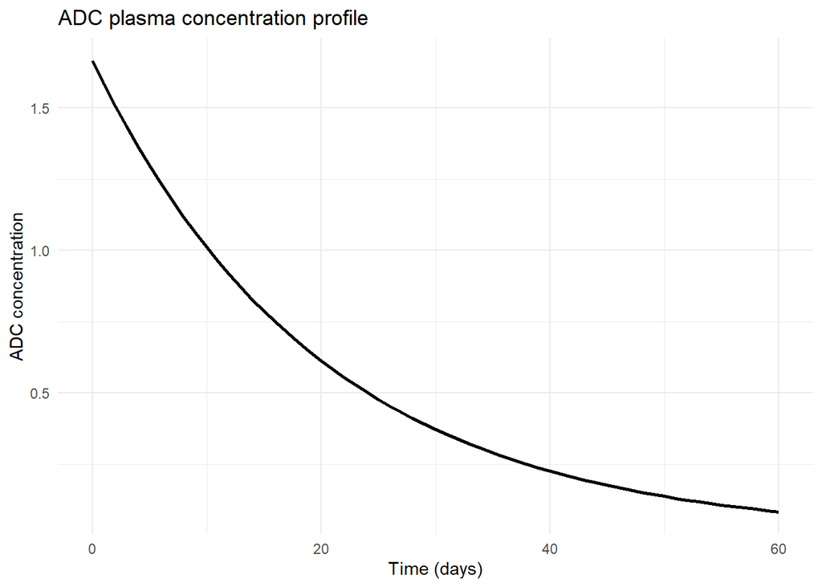

```r
dose <- 5     # mg/kg
V    <- 3     # L/kg
kel  <- 0.05  # day^-1

time_grid <- seq(0, 60, by = 1)  # days

adc_pk <- data.frame(
  time = time_grid,
  concentration = (dose / V) * exp(-kel * time_grid)
)

ggplot(adc_pk, aes(x = time, y = concentration)) +
  geom_line(linewidth = 1) +
  labs(title = "ADC plasma concentration profile", x = "Time (days)", y = "ADC concentration") +
  theme_minimal()
```

## 5. ADC pharmacodynamic model (Emax)

$$Effect(t) = \frac{E_{max} \times
C(t)}{EC_{50} + C(t)}$$

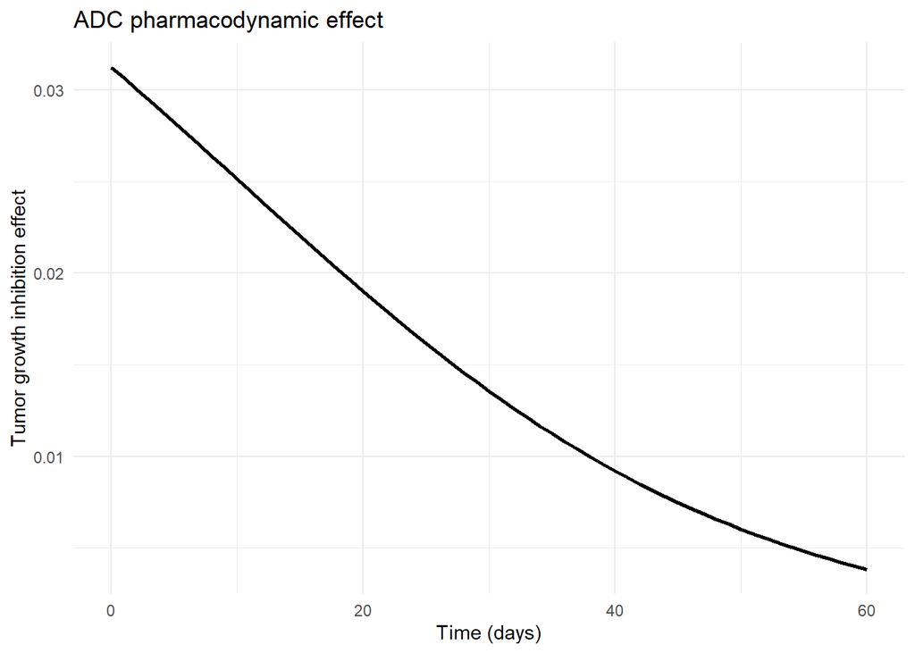

```r
Emax <- 0.05
EC50 <- 1

adc_pk <- adc_pk %>%
  mutate(inhibition = Emax * concentration / (EC50 + concentration))

ggplot(adc_pk, aes(x = time, y = inhibition)) +
  geom_line(linewidth = 1) +
  labs(title = "ADC pharmacodynamic effect", x = "Time (days)", y = "Tumor growth inhibition effect") +
  theme_minimal()
```

## 6. Tumor Growth Inhibition (single representative patient)

$$\frac{dSLD}{dt} = g_{daily} \times SLD -
Effect(t) \times SLD$$

The first term is intrinsic exponential growth; the second is drug-induced shrinkage. *Plasma ADC exposure is used here as a surrogate driver of pharmacodynamic activity in this simplified model — a real ADC acts through tumor distribution, internalization, and payload release, steps not represented individually here.* As ADC concentration declines, its effect fades and intrinsic growth eventually dominates again (single-dose scenario, no re-dosing).

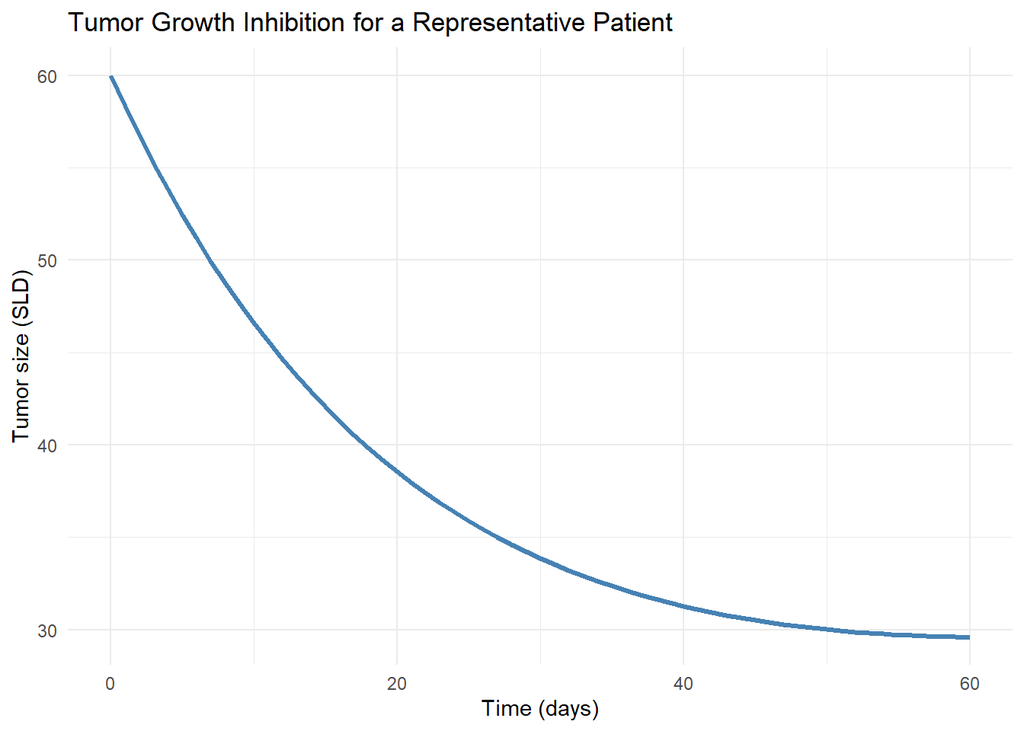

```r
g_daily_example <- 0.025 / 7
SLD0_example <- 60

tgi_data <- adc_pk
tgi_data$SLD <- NA
tgi_data$SLD[1] <- SLD0_example

for (i in 2:nrow(tgi_data)) {
  dt <- tgi_data$time[i] - tgi_data$time[i - 1]
  growth <- g_daily_example * tgi_data$SLD[i - 1]
  drug_effect <- tgi_data$inhibition[i - 1] * tgi_data$SLD[i - 1]
  tgi_data$SLD[i] <- tgi_data$SLD[i - 1] + (growth - drug_effect) * dt
}

ggplot(tgi_data, aes(x = time, y = SLD)) +
  geom_line(color = "steelblue", linewidth = 1.2) +
  labs(title = "Tumor Growth Inhibition for a Representative Patient",
       x = "Time (days)", y = "Tumor size (SLD)") +
  theme_minimal()
```

## 7. Population simulation with individual PK variability

Each patient is given their own elimination rate `kel_i` (log-normal, reflecting realistic inter-patient PK variability), and their own `g_daily` from Section 3. *For simplicity, inter-individual PK variability is introduced directly on `kel` rather than separately on clearance (CL) and volume of distribution (V), as would be done in a full population-PK model (`kel = CL/V`, with variability structured on `CL`).* For each patient we simulate **two** trajectories over the same 60-day window:

- `SLD` under ADC treatment (with the inhibition term)
- `SLD_no_drug`, the counterfactual trajectory with no drug effect (inhibition = 0)

The counterfactual is needed later for a fair “ADC vs. No ADC” survival comparison (Section 9) — both arms must be evaluated under the same hazard model, differing only in the tumor trajectory that feeds into it.

```r
patients <- patients %>%
  mutate(kel_i = rlnorm(n(), meanlog = log(0.05), sdlog = 0.20))

population_tgi <- data.frame()

for (i in 1:nrow(patients)) {
  g_i    <- patients$g_daily[i]
  kel_i  <- patients$kel_i[i]
  SLD0_i <- patients$SLD0[i]

  conc      <- (dose / V) * exp(-kel_i * time_grid)
  inhibition <- Emax * conc / (EC50 + conc)

  SLD          <- numeric(length(time_grid)); SLD[1] <- SLD0_i
  SLD_no_drug  <- numeric(length(time_grid)); SLD_no_drug[1] <- SLD0_i

  for (t in 2:length(time_grid)) {
    SLD[t]         <- SLD[t - 1] + (g_i * SLD[t - 1] - inhibition[t - 1] * SLD[t - 1])
    SLD_no_drug[t] <- SLD_no_drug[t - 1] + (g_i * SLD_no_drug[t - 1])  # pure growth, no drug
  }

  population_tgi <- bind_rows(
    population_tgi,
    data.frame(patient_id = patients$patient_id[i], time = time_grid,
               SLD = SLD, SLD_no_drug = SLD_no_drug)
  )
}

head(population_tgi)
```

```
##   patient_id time      SLD SLD_no_drug
## 1          1    0 89.55190    89.55190
## 2          1    1 87.26122    90.05972
## 3          1    2 85.09692    90.57041
## 4          1    3 83.05338    91.08400
## 5          1    4 81.12518    91.60051
## 6          1    5 79.30714    92.11994
```

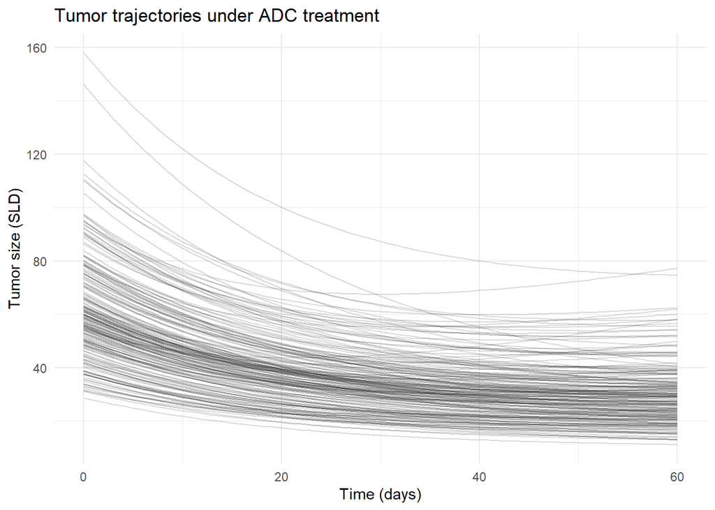

```r
ggplot(population_tgi, aes(time, SLD, group = patient_id)) +
  geom_line(alpha = 0.15) +
  labs(title = "Tumor trajectories under ADC treatment", x = "Time (days)", y = "Tumor size (SLD)") +
  theme_minimal()
```

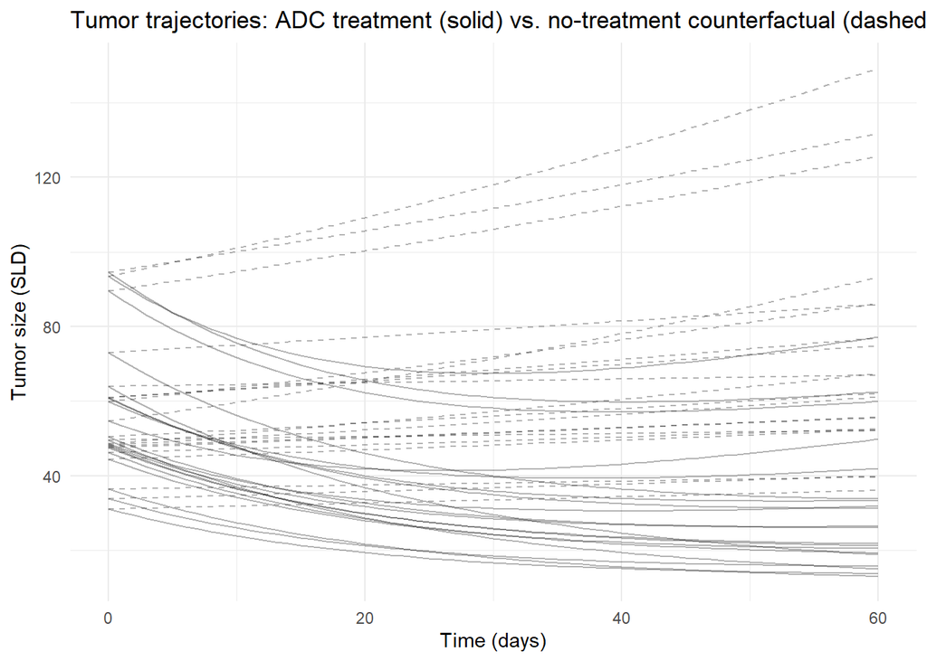

```r
# Direct visual comparison for a subset of patients: treated vs. untreated counterfactual
population_tgi %>%
  filter(patient_id <= 20) %>%
  ggplot(aes(x = time)) +
  geom_line(aes(y = SLD, group = patient_id), alpha = 0.3) +
  geom_line(aes(y = SLD_no_drug, group = patient_id), alpha = 0.3, linetype = "dashed") +
  labs(title = "Tumor trajectories: ADC treatment (solid) vs. no-treatment counterfactual (dashed)",
       x = "Time (days)", y = "Tumor size (SLD)") +
  theme_minimal()
```

## 8. Exposure-response analysis

Individual ADC exposure is summarized using the analytical AUC formula for a one-compartment IV bolus model with first-order elimination (AUC = Dose / (V × k_el)). Response is tumor size at day 60 (`SLD60`).

```r
patients <- patients %>%
  mutate(AUC = dose / (V * kel_i))

day60 <- population_tgi %>%
  filter(time == 60) %>%
  dplyr::select(patient_id, SLD60 = SLD, SLD60_no_drug = SLD_no_drug)

exposure_response <- patients %>%
  dplyr::select(patient_id, AUC, os_time, os_event) %>%
  left_join(day60, by = "patient_id")

summary(exposure_response$AUC)
```

```
##    Min. 1st Qu.  Median    Mean 3rd Qu.    Max.
##   19.42   29.37   33.44   34.16   37.66   60.65
```

```r
summary(exposure_response$SLD60)
```

```
##    Min. 1st Qu.  Median    Mean 3rd Qu.    Max.
##   11.16   21.76   28.84   30.31   35.61   77.24
```

```r
exposure_model <- lm(SLD60 ~ AUC, data = exposure_response)
summary(exposure_model)
```

```
##
## Call:
## lm(formula = SLD60 ~ AUC, data = exposure_response)
##
## Residuals:
##     Min      1Q  Median      3Q     Max
## -17.183  -6.873  -1.572   4.650  43.612
##
## Coefficients:
##             Estimate Std. Error t value Pr(>|t|)
## (Intercept)  59.6627     3.7448  15.932  < 2e-16 ***
## AUC          -0.8592     0.1075  -7.993 1.07e-13 ***
## ---
## Signif. codes:  0 '***' 0.001 '**' 0.01 '*' 0.05 '.' 0.1 ' ' 1
##
## Residual standard error: 10.35 on 198 degrees of freedom
## Multiple R-squared:  0.2439, Adjusted R-squared:  0.2401
## F-statistic: 63.88 on 1 and 198 DF,  p-value: 1.072e-13
```

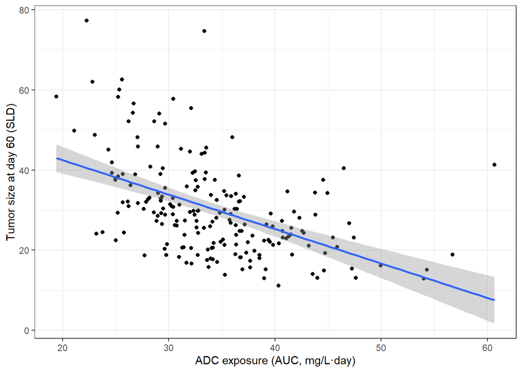

```r
ggplot(exposure_response, aes(x = AUC, y = SLD60)) +
  geom_point() +
  geom_smooth(method = "lm", se = TRUE) +
  theme_bw() +
  labs(x = "ADC exposure (AUC, mg/L\u00b7day)", y = "Tumor size at day 60 (SLD)")
```

**Interpretation.** A negative slope would indicate that higher ADC exposure is associated with stronger tumor inhibition at day 60 — the expected exposure-response relationship for an effective ADC.

## 9. Linking tumor response to survival: a landmark analysis

To connect tumor response to survival, we use `SLD60` — tumor burden at a fixed “landmark” time of day 60 — as a baseline predictor of subsequent survival. This is a standard, simple approach in oncology (landmark analysis), chosen here for interpretability; its main limitation is discussed in Section 10.

Both arms (ADC and its no-drug counterfactual) are evaluated under the **same** hazard structure, differing only in the tumor burden that feeds into it — this is what makes the comparison a fair counterfactual, unlike using two unrelated hazard formulas. In this simplified framework, `SLD60` is treated as a **prognostic biomarker** — a proxy for overall disease status — rather than a direct mechanistic driver of death; the hazard model below is a statistical association, not a claim about biological causality.

**Important:** the survival times computed below (`os_time`) represent *post-landmark* survival, measured from day 60 onward — not total overall survival from treatment initiation. The reported medians (e.g., “ADC: 536 days”) should be read as “536 days after the day-60 landmark”, not as total OS from day 0.

$$h_i = h_0 \times e^{\beta \times
(SLD60_i - \overline{SLD60})}$$

```r
baseline_hazard <- 0.002   # per day
beta_SLD <- 0.01

pooled_mean_SLD60 <- mean(c(exposure_response$SLD60, exposure_response$SLD60_no_drug))

survival_comparison <- bind_rows(
  exposure_response %>%
    transmute(patient_id, SLD60_used = SLD60, treatment = "ADC"),
  exposure_response %>%
    transmute(patient_id, SLD60_used = SLD60_no_drug, treatment = "No ADC")
) %>%
  mutate(
    hazard = baseline_hazard * exp(beta_SLD * (SLD60_used - pooled_mean_SLD60)),
    event_time_from_landmark = rexp(n(), rate = hazard),
    admin_censoring = 720,  # days of follow-up after the day-60 landmark
    os_time  = pmin(event_time_from_landmark, admin_censoring),
    os_event = as.integer(event_time_from_landmark <= admin_censoring)
  )

survival_comparison %>%
  group_by(treatment) %>%
  summarise(median_survival = median(os_time), mean_survival = mean(os_time))
```

```
## # A tibble: 2 × 3
##   treatment median_survival mean_survival
##   <chr>               <dbl>         <dbl>
## 1 ADC                  536.          463.
## 2 No ADC               271.          341.
```

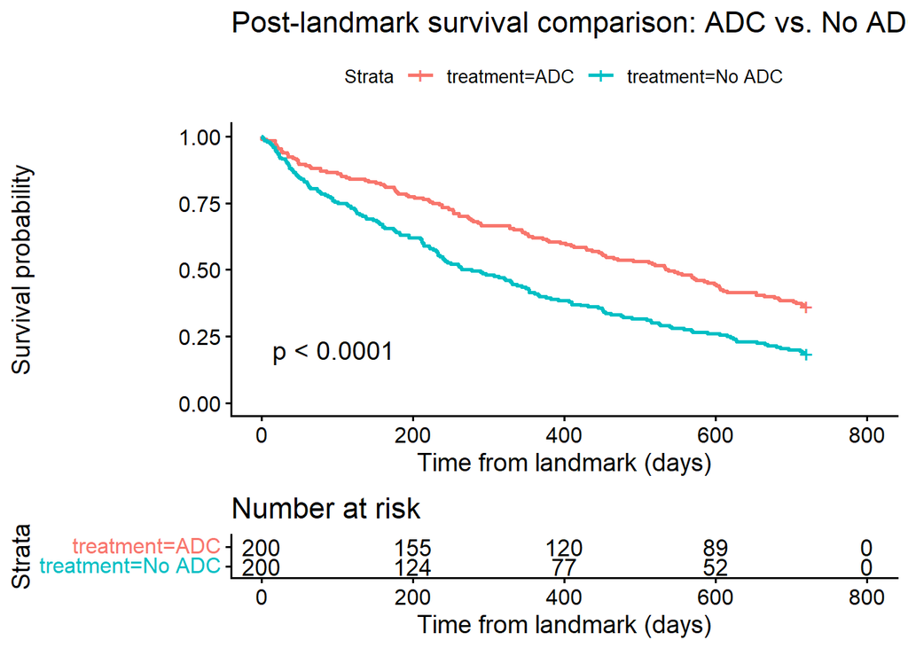

```r
km_fit <- survfit(Surv(os_time, os_event) ~ treatment, data = survival_comparison)

ggsurvplot(km_fit, data = survival_comparison, risk.table = TRUE, pval = TRUE,
           xlab = "Time from landmark (days)", ylab = "Survival probability",
           title = "Post-landmark survival comparison: ADC vs. No ADC (from day-60 landmark)")
```

## 10. Conclusion and limitations

This workflow demonstrates a complete, internally consistent PK/PD/TGI/survival chain: ADC pharmacokinetics determine drug concentration over time, which drives pharmacodynamic activity, which modifies tumor growth dynamics, which in turn is linked to survival through a shared hazard structure.

**Limitations, stated explicitly:**

- The TGI model here uses a single-dose exponential-growth/Emax-inhibition ODE, not the biexponential regrowth model from notebooks 1-2; it does not capture acquired resistance beyond simple loss of drug effect as concentration declines, and assumes no re-dosing. It also assumes an immediate relationship between ADC exposure and tumor shrinkage (a direct “kill” term), rather than a delayed or indirect-response structure (e.g., separate sensitive/resistant cell compartments), as used in some more mechanistic oncology TGI models.
- The landmark analysis (Section 9) avoids immortal-time bias by fixing tumor burden at a single time point, but discards potential early events before day 60 and depends on the choice of landmark time — a known trade-off of this method, not a flaw specific to this simulation.
- Euler integration with a 1-day step is used for simplicity; a smaller step size (or an ODE solver such as `deSolve::ode()`) would be more numerically robust for stiffer parameter combinations, and is the more standard implementation choice for pharmacometric ODE systems in general — not required here given the model’s stability over this time scale, but a natural next step if the model is extended.